# L4P2 - Exercícios com Testes de Hipótese

## Um Experimento com Sorrisos

Neste cenário, estamos estudando dados sobre como ver uma pessoa sorrindo muda o julgamento que temos dela. Os dados são de um experimento que mostrava para uma amostra de participantes 1 de quatro fotos, 3 das quais tem um sorriso e uma que não tem.

Essa foto era acompanhada de um texto que descrevia que a pessoa na foto era suspeita de ter plagiado um trabalho na universidade. Depois de ver a foto, as pessoa devem responder o quanto suspeitam ou não da pessoa retratada. O valor da coluna leniency é um índice feito de respostas para 5 perguntas em uma escala de 0 a 9. Ela mede o quão leniente foi o julgamento das pessoas. Repare que se apenas um sorriso causar alguma mudança, isso é impressionante. Por isso uma diferença de meio ponto já é considerada relevante.

(O estudo completo é esse, caso você tenha interesse: LaFrance, M., & Hecht, M. A. (1995) Why smiles generate leniency. Personality and Social Psychology Bulletin, 21, 207-214.)

### Carregamento e Análise Exploratória dos Dados

```r
q1_dados = read_csv(here::here("data/leniency.csv"),
                 col_types = "cdc")
```

### Questões

**1- Ter a pessoa sorrindo na foto (independente do sorriso) causa uma mudança no julgamento das pessoas em geral?**

```r
q1_theta_chapeu <- function(dados) {
  medias = dados %>%
    group_by(with_smile) %>%
    summarise(media=mean(leniency))

  smile = medias %>% filter(with_smile=="yes") %>% pull(media)
  nosmile = medias %>% filter(with_smile=="no") %>% pull(media)

  smile - nosmile
}

q1_amostra_theta_chapeu = round(q1_theta_chapeu(q1_dados),3)
```

```r
q1_theta_nulo <- function(dados) {
  random = dados %>%
    mutate(leniency_random=sample(leniency, n()))

  medias = random %>%
    group_by(with_smile) %>%
    summarise(media_populacao=mean(leniency_random))

  smile = medias %>% filter(with_smile=="yes") %>% pull(media_populacao)
  nosmile = medias %>% filter(with_smile=="no") %>% pull(media_populacao)

  smile - nosmile
}

q1_populacao_theta_nulo = replicate(5000, q1_theta_nulo(q1_dados))
```

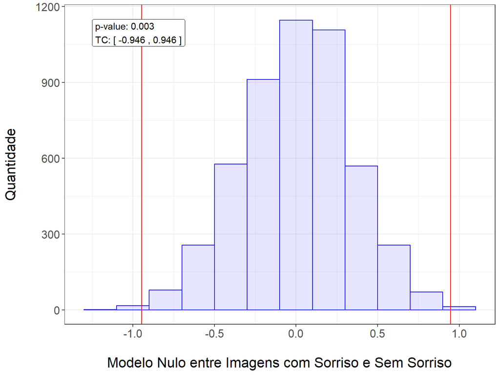

```r
q1_p_value = sum(abs(q1_populacao_theta_nulo) >= abs(q1_amostra_theta_chapeu)) / length(q1_populacao_theta_nulo)

tibble(media=q1_populacao_theta_nulo) %>%
  ggplot(aes(media)) +
  geom_histogram(binwidth=.2, alpha=.1, color='blue', fill='blue') +
  geom_vline(xintercept=q1_amostra_theta_chapeu, color='red') +
  geom_vline(xintercept=-q1_amostra_theta_chapeu, color='red') +
  annotate("label", x=-1.25, y=1150, hjust=0, vjust=1,
           label=paste("p-value:", round(q1_p_value,3), "\nTC: [", -q1_amostra_theta_chapeu, ",", q1_amostra_theta_chapeu, "]")) +
  labs(x=paste('\nModelo Nulo entre Imagens com Sorriso e Sem Sorriso'), y='Quantidade\n') +
  theme(text=element_text(size=16))
```

**2- Como se comparam os efeitos dos diferentes sorrisos no julgamento das pessoas?**

```r
q1_theta_chapeu_categ <- function(dados, tipo1, tipo2) {
  medias = dados %>%
    group_by(smile) %>%
    summarise(media=mean(leniency))

  smile1 = medias %>% filter(smile==tipo1) %>% pull(media)
  smile2 = medias %>% filter(smile==tipo2) %>% pull(media)

  smile1 - smile2
}
```

```r
q1_theta_nulo_categ <- function(dados, tipo1, tipo2) {
  random = dados %>%
    #filter(smile %in% c(tipo1, tipo2)) %>%
    mutate(leniency_random=sample(leniency, n()))

  medias = random %>%
    group_by(smile) %>%
    summarise(media_random=mean(leniency_random))

  smile1 = medias %>% filter(smile==tipo1) %>% pull(media_random)
  smile2 = medias %>% filter(smile==tipo2) %>% pull(media_random)

  smile1 - smile2
}
```

```r
q1_grafico_distribuicao_categ <- function(dados, tipo1, tipo2, theta_chapeu_grafico, p_value, xleg, yleg) {
  dados %>%
    ggplot(aes(media)) +
    geom_histogram(binwidth=.2, alpha=.1, color='blue', fill='blue') +
    geom_vline(xintercept=theta_chapeu_grafico, color='red') +
    geom_vline(xintercept=-theta_chapeu_grafico, color='red') +
    annotate("label", x=xleg, y=yleg, hjust=0, vjust=1,
             label=paste("p-value:", p_value, "\nTC: [", -theta_chapeu_grafico, ",", theta_chapeu_grafico, "]")) +
    labs(x=paste('\n', tipo1, 'e', tipo2), y='') +
    scale_x_continuous(breaks=c(-1,-theta_chapeu_grafico,0,theta_chapeu_grafico,1)) +
    theme(text=element_text(size=16))
}
```

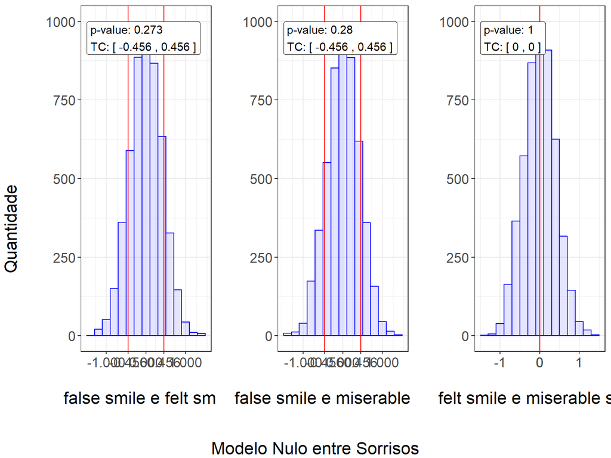

```r
q1_executa_comparacao <- function(dados, tipo1, tipo2) {
  q1_amostra_theta_chapeu_categ = q1_theta_chapeu_categ(dados, tipo1, tipo2)
  q1_populacao_theta_nulo_categ = replicate(5000, q1_theta_nulo_categ(dados, tipo1, tipo2))
  q1_p_value_categ = sum(abs(q1_populacao_theta_nulo_categ) >= abs(q1_amostra_theta_chapeu_categ)) / length(q1_populacao_theta_nulo_categ)
  #q1_p_value_categ
  q1_grafico_distribuicao_categ(tibble(media=q1_populacao_theta_nulo_categ),
                              tipo1, tipo2,
                              round(q1_amostra_theta_chapeu_categ,3),
                              round(q1_p_value_categ, 3),
                              -1.5, 1000)
}

graf_fal_fel = q1_executa_comparacao(q1_dados, "false smile", "felt smile")
graf_fal_mis = q1_executa_comparacao(q1_dados, "false smile", "miserable smile")
graf_fel_mis = q1_executa_comparacao(q1_dados, "felt smile", "miserable smile")

grid.arrange(graf_fal_fel,graf_fal_mis,graf_fel_mis, ncol=3,
             bottom = textGrob("\nModelo Nulo entre Sorrisos",
                               gp = gpar(fontsize=16)),
             left = textGrob("Quantidade", rot=90,
                               gp = gpar(fontsize=16)))
```

## Relação entre SAT e GPA

Nesse cenário, usaremos dados de resultados de duas avaliações feitas em alunos que se formaram em Computação em uma universidade pública americana.

O primeiro é o SAT: “O exame SAT é um teste padronizado que a maioria das faculdades dos EUA usa para determinar se os alunos devem ser aceitos na instituição.” e nossos dados tem a nota em matemática (math_SAT) e expressão verbal (verb_SAT) no SAT dos estudantes.

A segunda nota disponível é a GPA dos alunos, que você pode interpretar como um agregado do desempenho deles no curso. Temos o GPA deles para as matérias de computação (comp_GPA) e no geral (univ_GPA).

### Carregamento e Análise Exploratória dos Dados

```r
q2_dados = read_csv(here::here("data/sat-gpa.csv"),
                 col_types = "dddd")
```

```r
q2_theta_chapeu_cor <- function(dados, col) {

  cor(dados$comp_GPA, dados[[col]], method='pearson')
}

q2_theta_chapeu_cor_math = q2_theta_chapeu_cor(q2_dados, "math_SAT")
q2_theta_chapeu_cor_verb = q2_theta_chapeu_cor(q2_dados, "verb_SAT")
```

```r
q2_theta_nulo_cor <- function(dados, col) {

  random = dados %>%
    mutate(comp_GPA_random = sample(comp_GPA, n()))

  cor(random$comp_GPA_random, random[[col]], method='pearson')
}

q2_populacao_theta_nulo_math = replicate(5000, q2_theta_nulo_cor(q2_dados, "math_SAT"))
q2_p_value_math = sum(abs(q2_populacao_theta_nulo_math) >= abs(q2_theta_chapeu_cor_math)) / length(q2_populacao_theta_nulo_math)
q2_p_value_math
```

```
## [1] 0
```

```r
max(q2_populacao_theta_nulo_math)
```

```
## [1] 0.3346788
```

```r
q2_populacao_theta_nulo_verb = replicate(5000, q2_theta_nulo_cor(q2_dados, "verb_SAT"))
q2_p_value_verb = sum(abs(q2_populacao_theta_nulo_verb) >= abs(q2_theta_chapeu_cor_verb)) / length(q2_populacao_theta_nulo_verb)
q2_p_value_verb
```

```
## [1] 0
```

```r
max(q2_populacao_theta_nulo_verb)
```

```
## [1] 0.334627
```

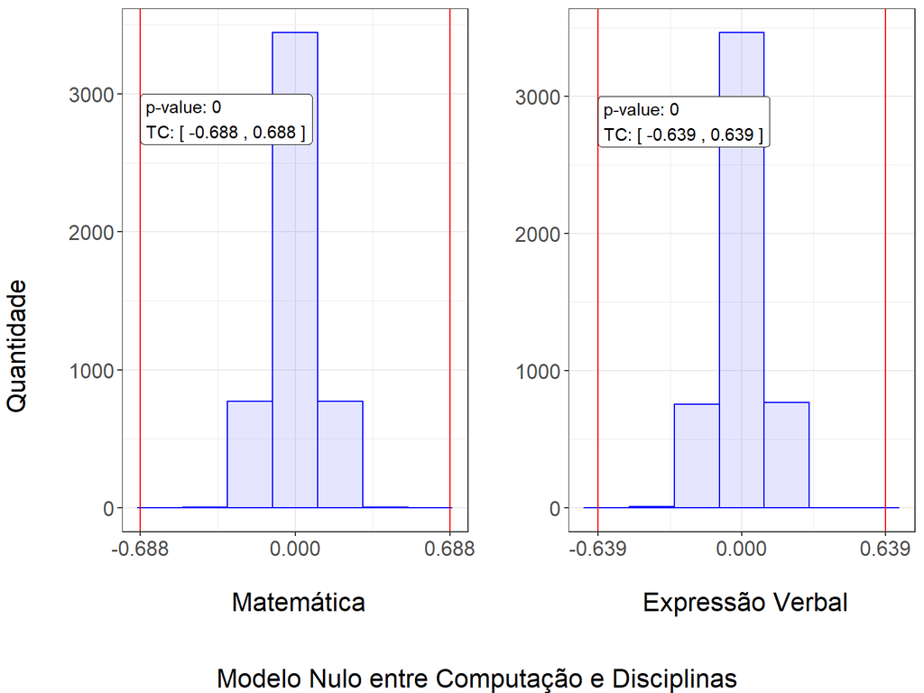

```r
q2_grafico_distribuicao <- function(dados, col, theta_chapeu_grafico, p_value, xleg, yleg) {
  dados %>%
    ggplot(aes(media)) +
    geom_histogram(binwidth=.2, alpha=.1, color='blue', fill='blue') +
    geom_vline(xintercept=theta_chapeu_grafico, color='red') +
    geom_vline(xintercept=-theta_chapeu_grafico, color='red') +
    annotate("label", x=xleg, y=yleg, hjust=0, vjust=1,
             label=paste("p-value:", p_value, "\nTC: [", -theta_chapeu_grafico, ",", theta_chapeu_grafico, "]")) +
    labs(x=paste('\n', col), y='') +
    scale_x_continuous(breaks=c(-1,-theta_chapeu_grafico,0,theta_chapeu_grafico,1)) +
    theme(text=element_text(size=16))
}

grafico_math = q2_grafico_distribuicao(tibble(media=q2_populacao_theta_nulo_math),
                        "Matemática",
                        round(q2_theta_chapeu_cor_math,3),
                        q2_p_value_math,
                        -round(q2_theta_chapeu_cor_math,3), 3000)

grafico_verb = q2_grafico_distribuicao(tibble(media=q2_populacao_theta_nulo_verb),
                        "Expressão Verbal",
                        round(q2_theta_chapeu_cor_verb,3),
                        q2_p_value_verb,
                        -round(q2_theta_chapeu_cor_verb,3), 3000)

grid.arrange(grafico_math, grafico_verb, ncol=2,
             bottom = textGrob("\nModelo Nulo entre Computação e Disciplinas",
                               gp = gpar(fontsize=16)),
             left = textGrob("Quantidade", rot=90,
                               gp = gpar(fontsize=16)))
```